## BC fish stock cards

Sablefish

Sablefish, BC coast

DFO 2024: Healthy Data tier A

2.94× LRP

Biomass relative to the limit reference point, 2021

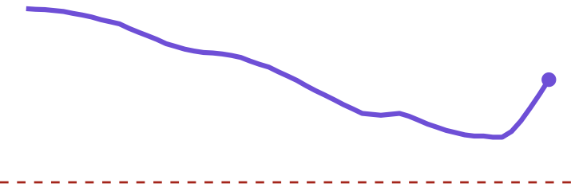

**Evidence**

Biomass and fishing pressure relative to MSY

**Managed by**

Fisheries and Oceans Canada (DFO)

**Status method**

Scientific Peer Review Process

**RAM assessment period**

1962-2021

**Biomass estimates**

1965 to 2021

**Data gaps and caveats**

- Time series ends in 2021; the DFO zone is from the 2024 survey.

Fun fact: Often sold as 'black cod', although it is not a true cod.

Coastwide stock; pin position is illustrative.

Pacific halibut

Pacific halibut, coastwide (Canada and US)

DFO 2024: Healthy Data tier A

1.88× LRP

Biomass relative to the limit reference point, 2020

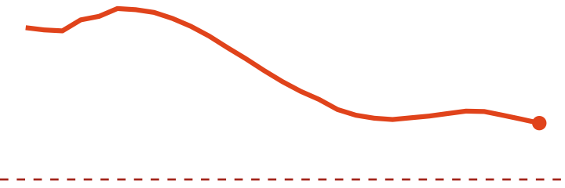

**Evidence**

Biomass and fishing pressure relative to MSY

**Managed by**

DFO, co-managed with United States of America via the International Pacific Halibut Commission

**Status method**

Scientific Peer Review Process

**RAM assessment period**

1992-2020

**Biomass estimates**

1992 to 2020

**Data gaps and caveats**

- Time series ends in 2020; the DFO zone is from the 2024 survey.
- Fishing-pressure ratio available only to 2013.
- Limit reference point taken or derived from RAM Legacy; DFO's current value may differ.

Fun fact: The largest flatfish in the North Pacific. As it grows, both eyes end up on one side of its head.

Coastwide stock; pin position is illustrative.

Pacific cod

Pacific cod, Queen Charlotte Sound and Hecate Strait

Not in DFO 2024 survey Data tier B

1.61× LRP

Biomass relative to the limit reference point, 2019

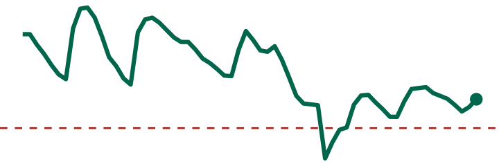

**Evidence**

Biomass relative to MSY only

**Managed by**

Fisheries and Oceans Canada (DFO)

**Status method**

Not reported

**RAM assessment period**

1953-2019

**Biomass estimates**

1956 to 2019

**Data gaps and caveats**

- Not included in DFO's 2024 Sustainability Survey, so there is no official status zone here.
- No fishing-pressure ratio relative to MSY, so no Kobe plot.
- Limit reference point taken or derived from RAM Legacy; DFO's current value may differ.

Fun fact: Also known as grey cod.

Pacific herring

Pacific herring, Strait of Georgia

DFO 2024: Healthy Data tier C

3.03× LRP

Biomass relative to the limit reference point, 2018

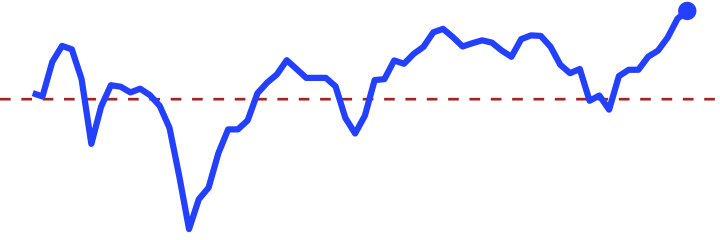

**Evidence**

Biomass and catch trends, no MSY ratios

**Managed by**

Fisheries and Oceans Canada (DFO)

**Status method**

Scientific Peer Review Process

**RAM assessment period**

1949-2018

**Biomass estimates**

1951 to 2018

**Data gaps and caveats**

- Time series ends in 2018; the DFO zone is from the 2024 survey.
- No fishing-pressure ratio relative to MSY, so no Kobe plot.
- Limit reference point taken or derived from RAM Legacy; DFO's current value may differ.

Fun fact: Herring spawn in shallow coastal water, laying sticky eggs on kelp and eelgrass.

Pacific herring

Pacific herring, West Coast of Vancouver Island

DFO 2024: Cautious Data tier C

1.45× LRP

Biomass relative to the limit reference point, 2018

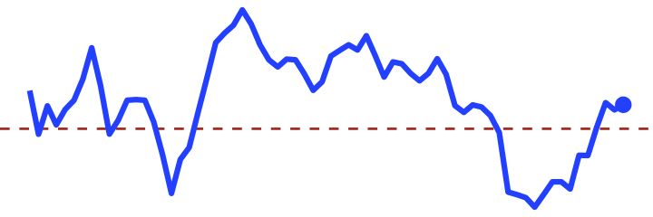

**Evidence**

Biomass and catch trends, no MSY ratios

**Managed by**

Fisheries and Oceans Canada (DFO)

**Status method**

Scientific Peer Review Process

**RAM assessment period**

1949-2018

**Biomass estimates**

1951 to 2018

**Data gaps and caveats**

- Time series ends in 2018; the DFO zone is from the 2024 survey.
- No fishing-pressure ratio relative to MSY, so no Kobe plot.
- Limit reference point taken or derived from RAM Legacy; DFO's current value may differ.

Fun fact: Herring spawn in shallow coastal water, laying sticky eggs on kelp and eelgrass.

Pacific herring

Pacific herring, Central Coast

DFO 2024: Cautious Data tier C

1.97× LRP

Biomass relative to the limit reference point, 2018

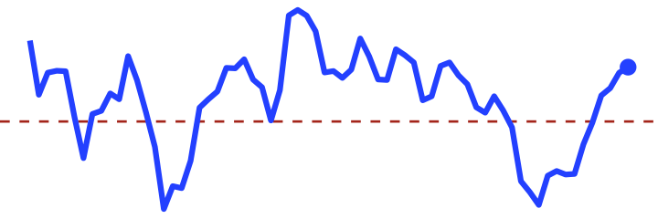

**Evidence**

Biomass and catch trends, no MSY ratios

**Managed by**

Fisheries and Oceans Canada (DFO)

**Status method**

Scientific Peer Review Process

**RAM assessment period**

1949-2018

**Biomass estimates**

1951 to 2018

**Data gaps and caveats**

- Time series ends in 2018; the DFO zone is from the 2024 survey.
- No fishing-pressure ratio relative to MSY, so no Kobe plot.
- Limit reference point taken or derived from RAM Legacy; DFO's current value may differ.

Fun fact: Herring spawn in shallow coastal water, laying sticky eggs on kelp and eelgrass.

Pacific herring

Pacific herring, Prince Rupert District

DFO 2024: Healthy Data tier C

1.36× LRP

Biomass relative to the limit reference point, 2018

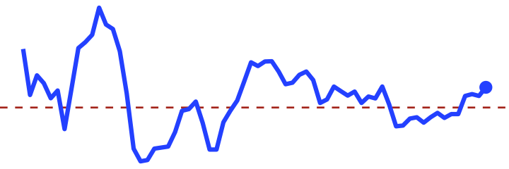

**Evidence**

Biomass and catch trends, no MSY ratios

**Managed by**

Fisheries and Oceans Canada (DFO)

**Status method**

Scientific Peer Review Process

**RAM assessment period**

1949-2018

**Biomass estimates**

1951 to 2018

**Data gaps and caveats**

- Time series ends in 2018; the DFO zone is from the 2024 survey.
- No fishing-pressure ratio relative to MSY, so no Kobe plot.
- Limit reference point taken or derived from RAM Legacy; DFO's current value may differ.

Fun fact: Herring spawn in shallow coastal water, laying sticky eggs on kelp and eelgrass.

Pacific herring

Pacific herring, Haida Gwaii

DFO 2024: Critical Data tier C

0.65× LRP

Biomass relative to the limit reference point, 2018

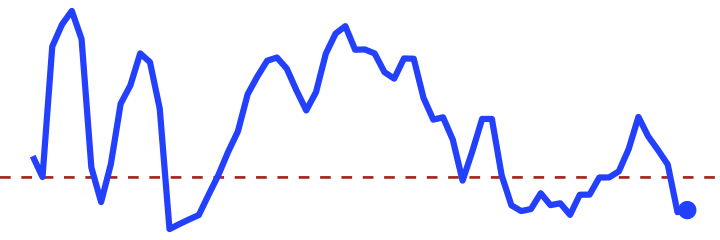

**Evidence**

Biomass and catch trends, no MSY ratios

**Managed by**

Fisheries and Oceans Canada (DFO)

**Status method**

Scientific Peer Review Process

**RAM assessment period**

1949-2018

**Biomass estimates**

1951 to 2018

**Data gaps and caveats**

- Time series ends in 2018; the DFO zone is from the 2024 survey.
- No fishing-pressure ratio relative to MSY, so no Kobe plot.
- Limit reference point taken or derived from RAM Legacy; DFO's current value may differ.

Fun fact: Herring spawn in shallow coastal water, laying sticky eggs on kelp and eelgrass.

Spot prawn

Spot prawn, BC coast

DFO 2024: Healthy Data tier D

No biomass time series compiled for this stock.

**Evidence**

DFO status zone only, no assessment time series compiled

**Managed by**

Fisheries and Oceans Canada (DFO)

**Status method**

Scientific Peer Review Process

**RAM assessment period**

Not in RAM Legacy

**Biomass estimates**

None compiled

**Data gaps and caveats**

- No public assessment time series compiled in this project; status relies on DFO's survey response.

Fun fact: Spot prawns start life as males and later change to females.

Coastwide stock; pin position is illustrative.

Dungeness crab

Dungeness crab, BC coast

DFO 2024: Healthy Data tier D

No biomass time series compiled for this stock.

**Evidence**

DFO status zone only, no assessment time series compiled

**Managed by**

Fisheries and Oceans Canada (DFO)

**Status method**

Expert Judgement

**RAM assessment period**

Not in RAM Legacy

**Biomass estimates**

None compiled

**Data gaps and caveats**

- No public assessment time series compiled in this project; status relies on DFO's survey response.
- DFO status based on expert judgement rather than a model-based assessment.

Fun fact: Named after Dungeness, a small town in Washington State.

Coastwide stock; pin position is illustrative.